# SysBio Day 2 Hands On

## Overview

In today's practice we will be focusing on data visualization with ggplot.

You can find a useful cheatsheet for `ggplot2` and other common R packages in the RStudio website: https://www.rstudio.com/resources/cheatsheets/

## 1) Loading packages and data

Most of the methods explained during the class are part of `R-basics`. Thus their installation are not required.

Still, we will need to install the following packages

```r
install.packages('Rtsne')
install.packages('ggplot2')
install.packages('magrittr')
install.packages('stringr')
install.packages('plyr')
install.packages('dplyr')
install.packages('tidyr')
install.packages('pheatmap')
```

### Loading necessary packages

```r
library(Rtsne)
library(ggplot2)
library(magrittr)
library(stringr)
library(plyr)
library(dplyr)
library(tidyr)
library(pheatmap)
```

### Load the data

Load the expression and annotation data we saved yesterday:

```r
data = readRDS('~/SysBio_day1_2/lapatinib_expression.rds')
meta = readRDS('~/SysBio_day1_2/lapatinib_phenotype.rds')
```

## 4) Generating barplot

Let's create a barplot to see how many samples we have per tissue. First we will count how many samples per tissue we have in our data set and generate a list of colors for each one.

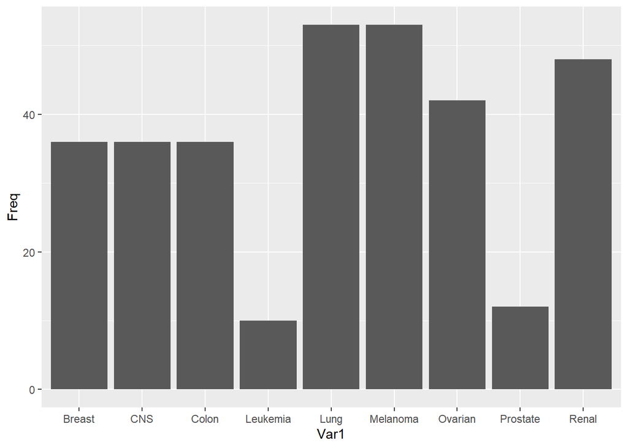

```r
#Remove special characters from metadata column names (using pipe function %>% [ctr/cmd+shift+m])
colnames(meta) <- colnames(meta) %>% str_replace_all(":", ".")

#Create summary table
tissue.sum <- table(meta$tissue.ch1) %>% as.data.frame()

#Create ggplot item
ggp <- ggplot(tissue.sum, aes(x=Var1, y=Freq))

#Add bar feature
ggp + geom_col()
```

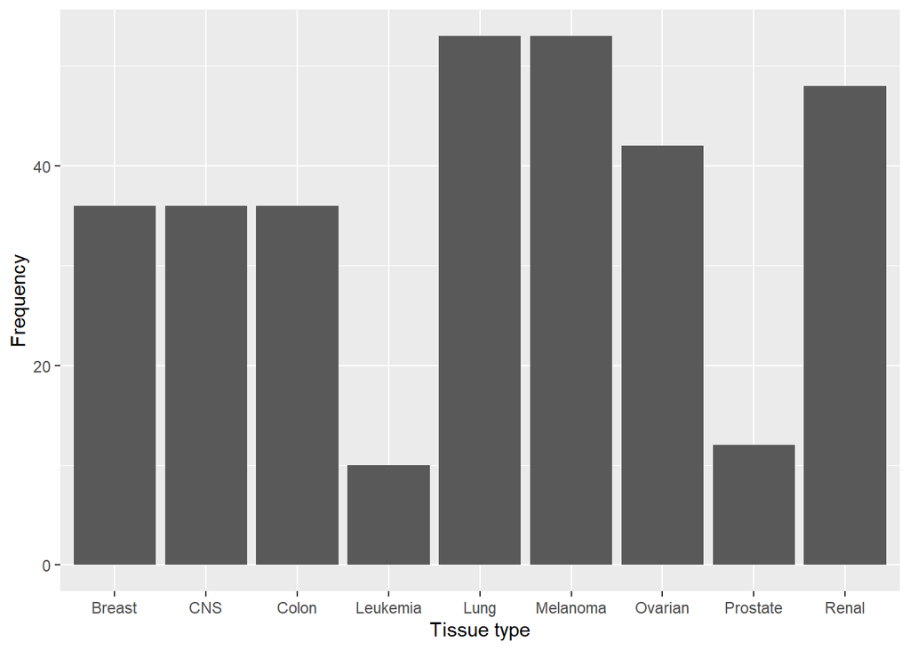

```r
#Change x and y labels
ggp + geom_col() +
  xlab("Tissue type") +
  ylab("Frequency")
```

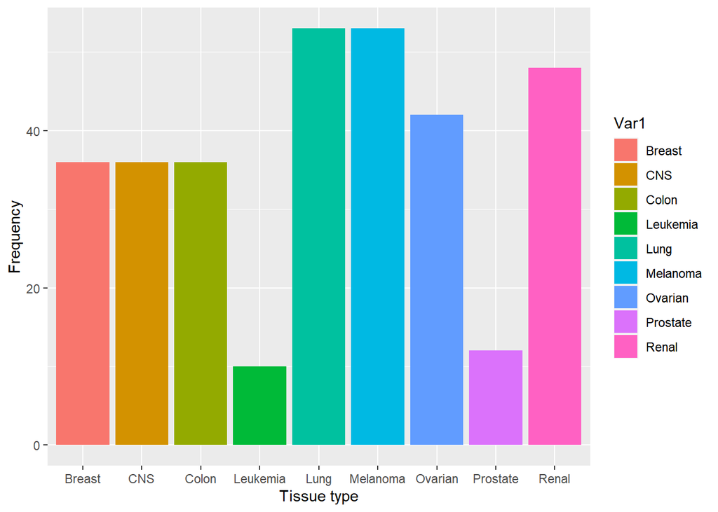

```r
## Add colours

#Recreate ggplot item
ggp <- ggplot(tissue.sum, aes(x=Var1, y=Freq, fill=Var1))

ggp + geom_col() +
  xlab("Tissue type") +
  ylab("Frequency")
```

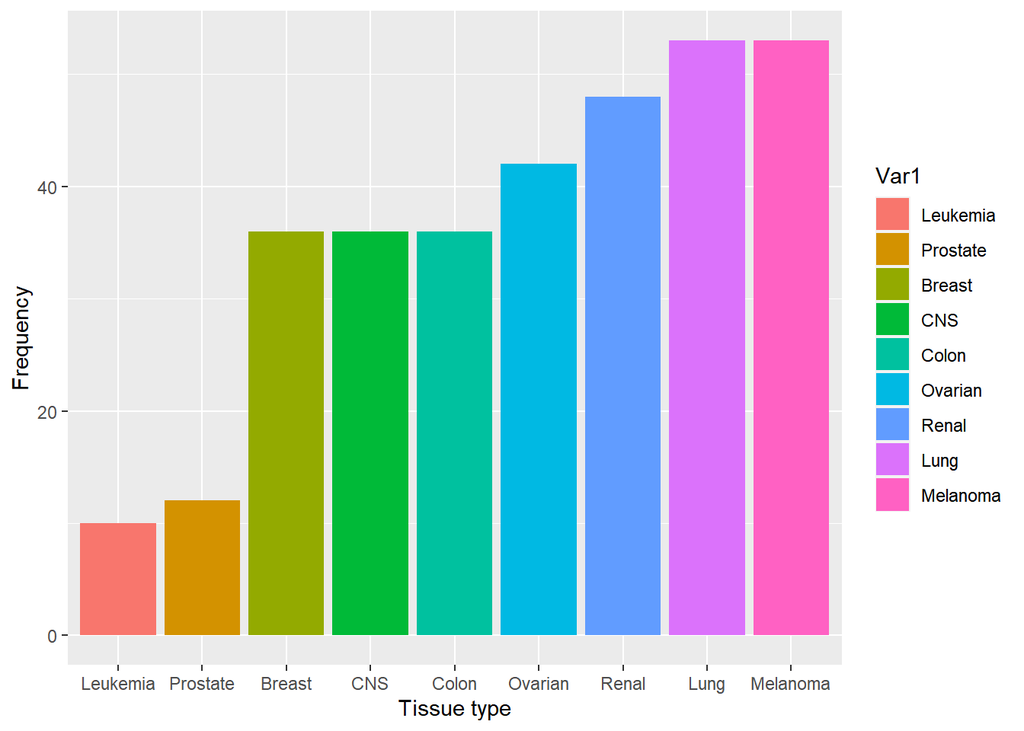

```r
#Change data order -- working with factors

#Look at current factor
tissue.sum$Var1

#What happens if we sort the table and check the factor again
tissue.sum[order(tissue.sum$Freq, decreasing = FALSE),]$Var1

#Create correct levels order
new.levels <- tissue.sum[order(tissue.sum$Freq, decreasing = FALSE),]$Var1 %>% as.character()

tissue.sum$Var1 <- factor(tissue.sum$Var1, new.levels)

#Recreate ggplot item
ggp <- ggplot(tissue.sum, aes(x=Var1, y=Freq, fill=Var1))

ggp + geom_col() +
  xlab("Tissue type") +
  ylab("Frequency")
```

```r
########
# TASK #
########

##Replot with the tissue types in decreasing order (largest first)
```

# Summarising data with group_by

```r
#Select specific columns
meta.drugcount <- meta %>% subset(select=c(tissue.ch1, drug_conc)) %>%
  #Group by columns of interest
  group_by(tissue.ch1, drug_conc) %>%
  #Count number of occurences of each drug concentration by evaluating the length of the group
  mutate(count=length(drug_conc)) %>%
  #Remove duplicate rows
  unique()

########
# TASK #
########

##Create meta.drugtime using the above technique and the drug_tpoint column
```

## 5) Basic statistics

Let us first compute some summary statistics and plot them across samples in order to get a preliminary idea of our expression data.

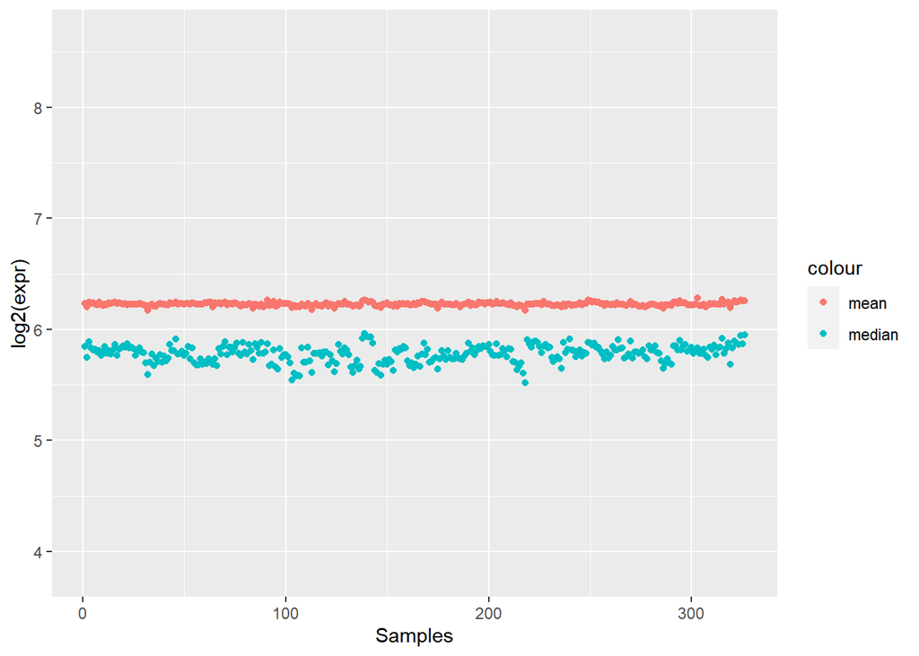

```r
#Calculate key stats of expression data
c_mean = colMeans(data)
c_median = apply(data, 2, median)
c_std = apply(data, 2, sd)

#Create numeric values of samples (equivalent to sample names)
rng = 1:length(c_mean)

#Put into dataframe
sumstats = data.frame(c_mean=c_mean,
                      c_median=c_median,
                      c_std=c_std,
                      rng=rng)

#Create geom_point plot using x as a range of sample "numbers" and y as log2(expr), adding both median and mean values
statplot <- ggplot(sumstats, aes(x=rng, y=c_median)) +
  #Add points for median (setting legend label to median)
  geom_point(aes(color="median")) +
  #Add points for mean
  geom_point(aes(x=rng, y=c_mean, color="mean")) +
  #Set y range from lower to upper std deviations
  ylim(range(c(c_mean-c_std, c_mean+c_std))) +
  #Change y axis label
  ylab("log2(expr)") +
  #Change x axis label
  xlab("Samples")

statplot
```

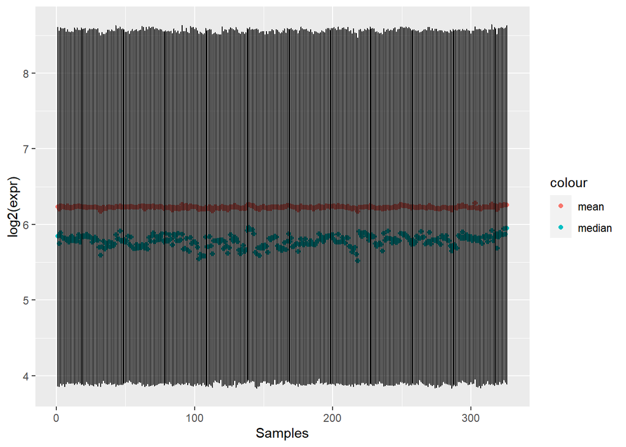

```r
#Adding error bars
statplot +
  geom_errorbar(aes(ymin=c_mean-c_std, ymax=c_mean+c_std), width=.2)
```

## 6) Boxplots

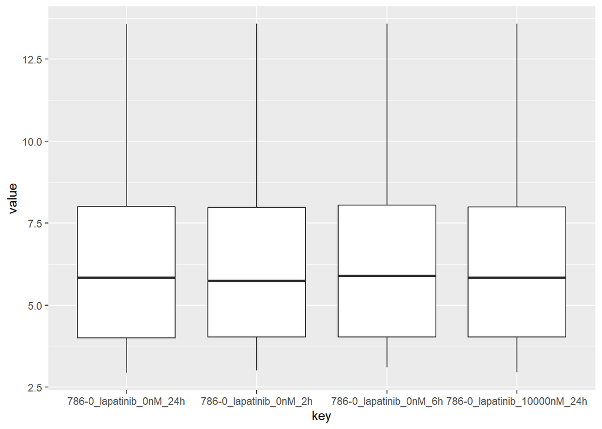

```r
#Box plots usually calculate their own summary statistics, so they need to be given the entire sample matrix
#However we first need to put that into long format
melted.data <- data %>% gather()

#Select first four samples only (otherwise boxplot would be unreadable)
smps <- meta$title[1:4]

short <- melted.data[melted.data$key %in% smps,]

#Create boxplot
ggplot(short, aes(x=key, y=value)) +
  geom_boxplot()
```

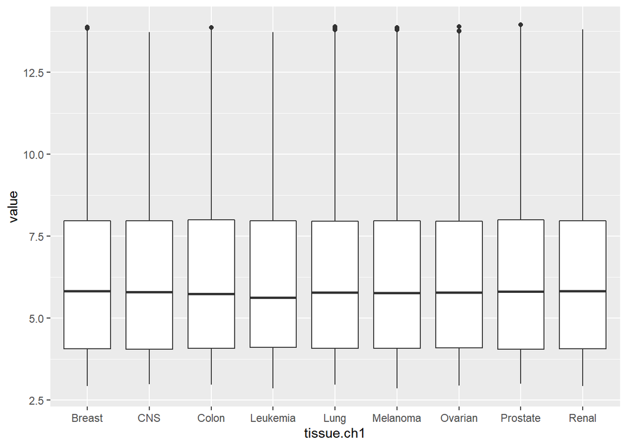

```r
#Merge summary stats with meta data
merged.meta <- merge(melted.data, meta, by.x="key", by.y="title", all.x=TRUE)

#Create boxplot
ggplot(merged.meta, aes(x=tissue.ch1, y=value)) +
  geom_boxplot()
```

```r
########
# TASK #
########

##Create box plot showing expression statistics per drug concentration

#Did it work? are you sure?
```

## 7) Histogram + density

Now we select a sample and see how the expression data distribution looks like. To do this we can plot the histogram or the density plot (or both).

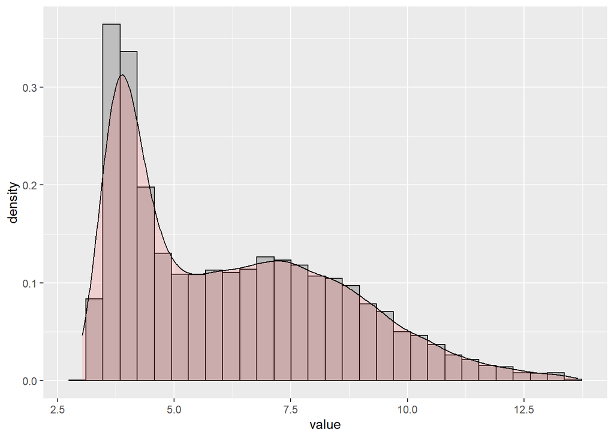

```r
#Set sample that we want to look at
sample_name = "A498_lapatinib_10000nM_24h"

#Select that sample from our data
data.smp <- melted.data[melted.data$key == sample_name,]

#Create histogram of expression values with density
ggplot(data.smp, aes(x=value)) +
  geom_histogram(aes(y=..density..), color="black", fill="grey") +
  geom_density(alpha=.2, fill="#FF6666")
```

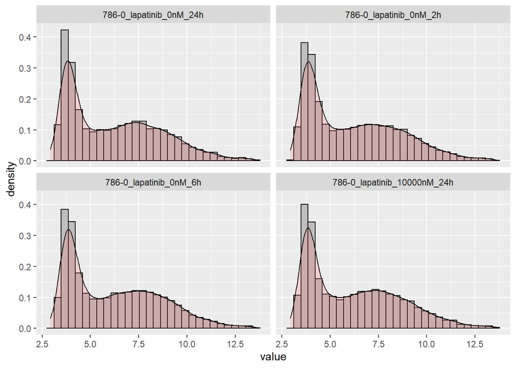

```r
#Now lets do this for 4 samples and show it in a facet_wrap

#Select that sample from our data (using smps variable we created before)
data.smp <- melted.data[melted.data$key %in% smps,]

#Create histogram of expression values with density
ggplot(data.smp, aes(x=value)) +
  geom_histogram(aes(y=..density..), color="black", fill="grey") +
  geom_density(alpha=.2, fill="#FF6666") +
  facet_wrap(~key)
```

### Finished with our quality/summary stats, lets clean our environment

```r
rm(list=setdiff(ls(), c("data", "meta")))
```

## 8) Heatmap + hierarchical clustering

Now we will plot the heatmap of our expression profiles along with the hierarchical clustering. On top of that, we will show the tissue of origin with colors (which can nicely be done in a single function in base R):

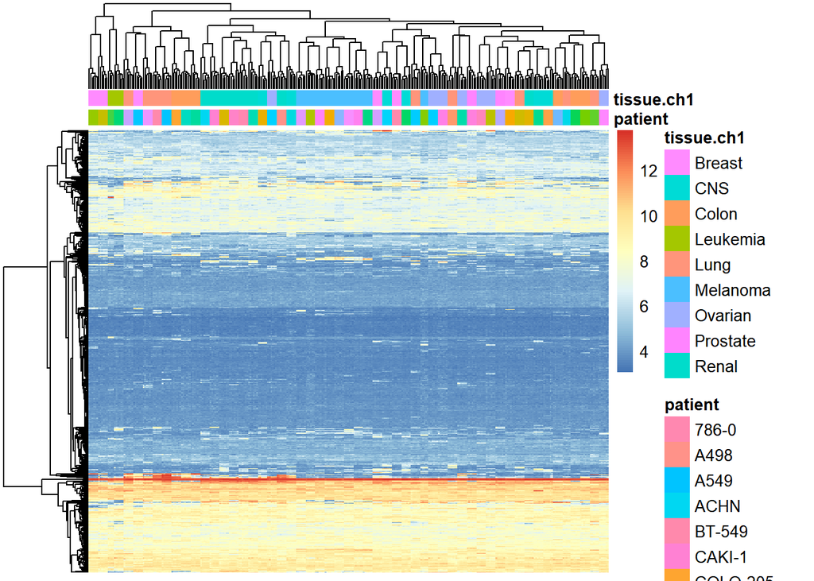

```r
## Create an annotation df

# Create patient name column (sapply: apply over list, '[': get element, 1: first element)
meta$patient <- sapply(strsplit(meta$title, "_"), `[`, 1)

anno <- meta %>% subset(select=c(title, patient, tissue.ch1))

row.names(anno) <- anno$title

anno <- anno[-1]

#Create short version for quick plotting
data.short <- data[1:500,]

#Plot data
pheatmap(as.matrix(data.short), annotation_col = anno, show_rownames=FALSE, show_colnames=FALSE)
```

## 9) Scatter plot and correlation

Melanoma samples seem to cluster together, let's see how well they correlate:

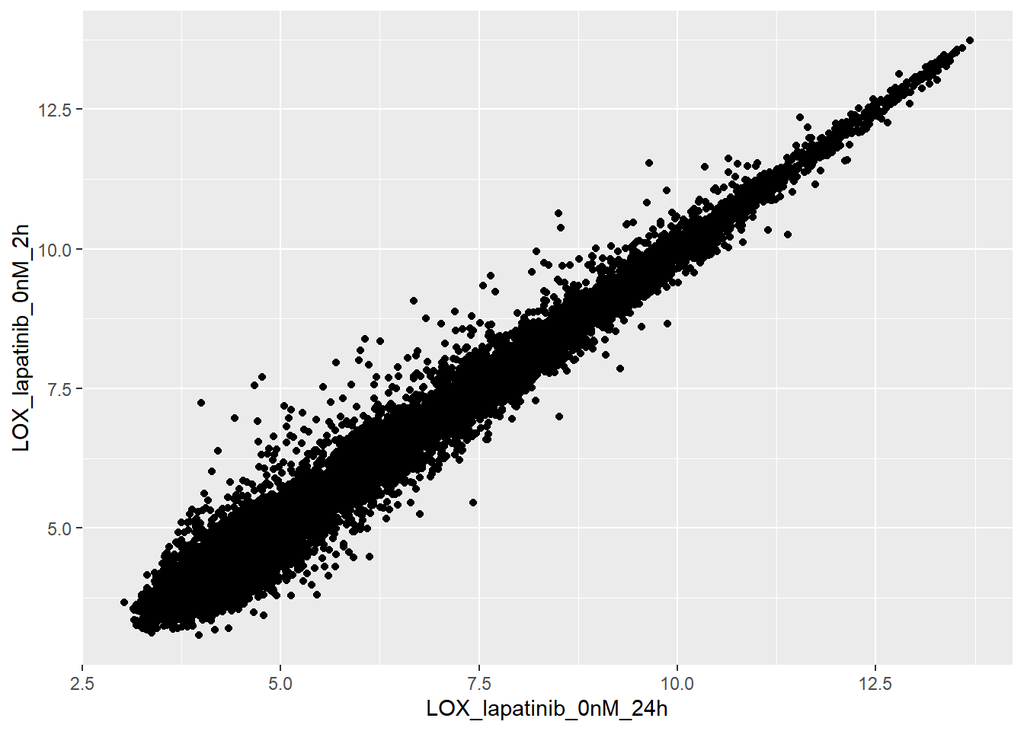

```r
#Find names of melanoma samples
usecols <- meta[meta$tissue.ch1 == 'Melanoma',]$title

## Plot correlation of first two samples
#Select data for first two samples
data.corr <- data %>% subset(select=c(usecols[1], usecols[2]))

#Plot
ggplot(data.corr, aes_string(x=usecols[1], y=usecols[2])) +
  geom_point()
```

```r
#Find correlation of all samples
cor(data[, usecols])

#Find mean of correlations
cor(data[, usecols]) %>% mean()
```

## 10) PCA on gene expression profiles of treated cell lines

Next, a Principal Component Analysis (PCA) is performed on the data to assess the main sources of variability across the gene expression profiles. In order to do this, we first define a simple function that shows the most relevant information from the PCA (i.e. the first 2 principal components and how much variance each one explains).

```r
# Perform PCA using prcomp function
# Note: the matrix must be transposed, so samples are rows
pca.n <- prcomp(t(data))

#Generating function created by colleague that plots PCA data
plotPCA <- function(pca, pchs=21, colour=NULL, PCs=c("PC1", "PC2")){
  # stopifnot(pca)
  # stopifnot(length(PCs) == 2)
  tmp <- summary(pca)
    # importance: variance explained
    PCx <- format(round(tmp$importance[2, PCs[1]] * 100, digits=2), nsmall=2)
    PCy <- format(round(tmp$importance[2, PCs[2]] * 100, digits=2), nsmall=2)
  x <- data.frame(pca$x)

  #Merge PCs back to metadata for annotation (may need to change by.y for other metadatas)
  merged <- x %>% subset(select=PCs) %>% merge(., meta, by.x="row.names", by.y="title")

  # Plot
  ggplot(merged, aes_string(x=PCs[1], y=PCs[2], colour=colour)) +
    geom_point() +
    xlab(paste(PCs[1], "(", PCx, "% var. expl.)", sep="")) +
    ylab(paste(PCs[2], "(", PCy, "% var. expl.)", sep=""))

}
```

Now let's plot it!

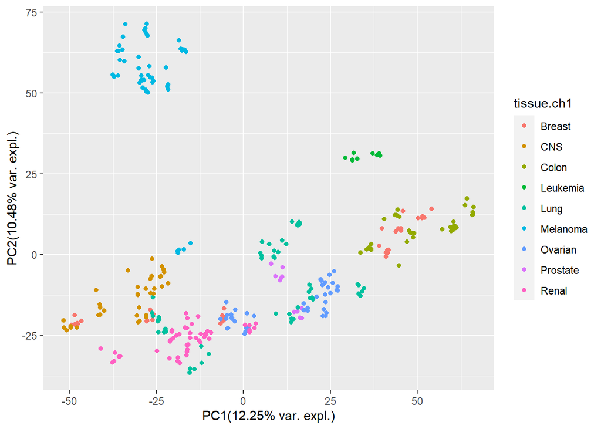

```r
#Run previously generated function
plotPCA(pca.n, PCs=c("PC1", "PC2"), colour="tissue.ch1")
```

```r
########
# TASK #
########

#Try plotting the PCA using a different annotation column such as patient
```

## 11) t-SNE

t-distributed Stochastic Neighbour Embedding is another dimensionality reduction algorithm (originally developed by Laurens Van der Maaten) that has gained a lot of importance in the last years. One of its major improvements from the common PCA is that is able to reveal some non-linear relations across (multi- dimensional) data points. As a drawback, the parameter choice is non-trivial and the obtained results may vary depending on the pseudo-random number generator seed (stochastic implies randomness by definition).

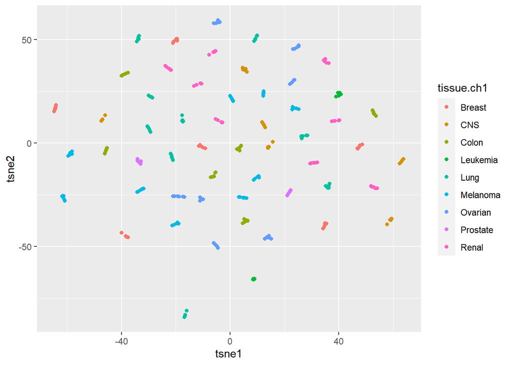

```r
# perplexity should be 3 * perplexity < nrow(X) - 1 (default=50)
# theta is speed/accuracy ratio. 1 is max speed, 0 max accuracy (default=0.5)
tsne_data = Rtsne(t(data), perplexity=3, theta=0.5) # NOTE: Transposed matrix!

#Bind tsne values with metadata
merged.tsne <- cbind(tsne_data$Y, meta)

#Add colnames for tsne values
colnames(merged.tsne)[1:2] <- c("tsne1", "tsne2")

#Plot
ggplot(merged.tsne, aes(x=tsne1, y=tsne2, colour=tissue.ch1)) +
  geom_point()
```